# THE COVID-19 PANDEMIC IN HUNGARY

K.M.N.Jayathilaka AS2019400

10/5/2022

# 1. Introduction

- Hungary

Hungary is a landlocked country in Central Europe. Spanning 93,030 square kilo meters (35,920 sq mi) of the Carpathian Basin, it is bordered by Slovakia to the north, Ukraine to the northeast, Romania to the east and southeast, Serbia to the south, Croatia and Slovenia to the southwest, and Austria to the west. Hungary has a population of nearly 10 million, mostly ethnic Hungarians and a significant Romani minority. Hungarian, the official language, is the world’s most widely spoken Uralic language and among the few non-Indo-European languages widely spoken in Europe.

- Health Condition in Hungary

Hungary maintains a universal health care system largely financed by government national health insurance. According to the OECD, 100% of the population is covered by universal health insurance, which is free for children, students, pensioners, people with low income, handicapped people, and church employees. Hungary spends 7.2% of GDP on healthcare, spending $2,045 per capita, of which $1,365 is provided by the government. here are considerable health disparities between the western and eastern parts of Hungary; heart disease, hypertension, stroke, and suicide is prevalent in the mostly agricultural and low-income Great Plain region in the east, but infrequent in the high-income, middle class areas of Western Transdanubia and Central Hungary. Smoking is a leading cause of death in the country

- Covid-19 pandemic situation in Hungary

The COVID-19 pandemic in Hungary is part of the ongoing worldwide pandemic of coronavirus disease 2019 (COVID-19) caused by severe acute respiratory syndrome coronavirus 2 (SARS-CoV-2). On 4 March 2020, the first cases in Hungary were announced. On March 18, 2020, Surgeon general Cecília Müller announced that the virus had spread to every part of the country.As of June 2021, Hungary has the second-highest COVID-19 death rate in the world. The first two known cases were students from Iran, who were studying in Hungary. One of them was enrolled at the Pharmacy Faculty of Semmelweis University. The student did not comply with the preventive measures required by the university as a precaution. He already visited his primary care physician and he was diagnosed with bacterial infection so that he didn’t have to quarantine himself, and instead, he attended courses held in English with 16 other students. The other person studied at the Hungarian University of Agriculture and Life Sciences in Gödöllő, who after returning from Iran, went to a self-declared quarantine. He did not attend lectures at the university, but went to Saint Ladislaus Hospital, and declared that he had arrived from an infected territory. Both of them were transported to Saint Ladislaus Hospital. They had mild symptoms. They arrived back in Hungary on 26 and 28 February 2020.

- Location

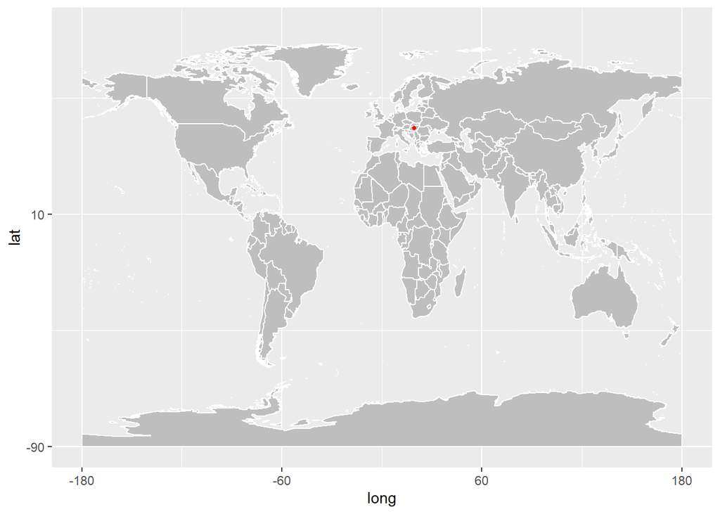